# EDA

```python
import numpy as np # linear algebra
import pandas as pd # data processing, CSV file I/O (e.g. pd.read_csv)
import os
from glob import glob
%matplotlib inline
import matplotlib.pyplot as plt
import seaborn as sns
from itertools import chain
import pydicom
##Import any other packages you may need here
```

EDA is open-ended, and it is up to you to decide how to look at different ways to slice and dice your data. A good starting point is to look at the requirements for the FDA documentation in the final part of this project to guide (some) of the analyses you do.

This EDA should also help to inform you of how pneumonia looks in the wild. E.g. what other types of diseases it's commonly found with, how often it is found, what ages it affects, etc.

Note that this NIH dataset was not specifically acquired for pneumonia. So, while this is a representation of 'pneumonia in the wild,' the prevalence of pneumonia may be different if you were to take only chest x-rays that were acquired in an ER setting with suspicion of pneumonia.

Perform the following EDA:

- The patient demographic data such as gender, age, patient position,etc. (as it is available)
- The x-ray views taken (i.e. view position)
- The number of cases including:
  - number of pneumonia cases,
  - number of non-pneumonia cases
- The distribution of other diseases that are comorbid with pneumonia
- Number of disease per patient
- Pixel-level assessments of the imaging data for healthy & disease states of interest (e.g. histograms of intensity values) and compare distributions across diseases.

Note: use full NIH data to perform the first a few EDA items and use `sample_labels.csv` for the pixel-level assassements.

Also, **describe your findings and how will you set up the model training based on the findings.**

```python
## Below is some helper code to read data for you.
## Load NIH data
all_xray_df = pd.read_csv('/data/Data_Entry_2017.csv')
all_xray_df.sample(3)
```

|  | Image Index | Finding Labels | Follow-up # | Patient ID | Patient Age | Patient Gender | View Position | OriginalImage[Width | Height] | OriginalImagePixelSpacing[x | y] | Unnamed: 11 |
| --- | --- | --- | --- | --- | --- | --- | --- | --- | --- | --- | --- | --- |
| 30463 | 00007946_004.png | Atelectasis | 4 | 7946 | 58 | M | AP | 2500 | 2048 | 0.168 | 0.168 | NaN |
| 44611 | 00011463_001.png | Cardiomegaly | 1 | 11463 | 29 | F | PA | 2442 | 2461 | 0.143 | 0.143 | NaN |
| 69049 | 00017040_000.png | Atelectasis\|Fibrosis | 0 | 17040 | 51 | M | PA | 2662 | 2688 | 0.143 | 0.143 | NaN |

```python
all_xray_df.columns
```

```
Index(['Image Index', 'Finding Labels', 'Follow-up #', 'Patient ID',
       'Patient Age', 'Patient Gender', 'View Position', 'OriginalImage[Width',
       'Height]', 'OriginalImagePixelSpacing[x', 'y]', 'Unnamed: 11'],
      dtype='object')
```

```python
## Load 'sample_labels.csv' data for pixel level assessments
sample_df = pd.read_csv('sample_labels.csv')
sample_df.sample(3)
```

|  | Image Index | Finding Labels | Follow-up # | Patient ID | Patient Age | Patient Gender | View Position | OriginalImageWidth | OriginalImageHeight | OriginalImagePixelSpacing_x | OriginalImagePixelSpacing_y |
| --- | --- | --- | --- | --- | --- | --- | --- | --- | --- | --- | --- |
| 5376 | 00029018_000.png | No Finding | 0 | 29018 | 032Y | M | PA | 3056 | 2544 | 0.139 | 0.139 |
| 2628 | 00013209_013.png | Pneumothorax | 13 | 13209 | 074Y | F | PA | 2992 | 2991 | 0.143 | 0.143 |
| 3040 | 00014949_000.png | No Finding | 0 | 14949 | 055Y | F | AP | 2048 | 2500 | 0.168 | 0.168 |

```python
sample_df.columns
```

```
Index(['Image Index', 'Finding Labels', 'Follow-up #', 'Patient ID',
       'Patient Age', 'Patient Gender', 'View Position', 'OriginalImageWidth',
       'OriginalImageHeight', 'OriginalImagePixelSpacing_x',
       'OriginalImagePixelSpacing_y'],
      dtype='object')
```

```python
all_xray_df.dtypes
```

```
Image Index                     object
Finding Labels                  object
Follow-up #                      int64
Patient ID                       int64
Patient Age                      int64
Patient Gender                  object
View Position                   object
OriginalImage[Width              int64
Height]                          int64
OriginalImagePixelSpacing[x    float64
y]                             float64
Unnamed: 11                    float64
dtype: object
```

```python
all_xray_df.info()
```

```
<class 'pandas.core.frame.DataFrame'>
RangeIndex: 112120 entries, 0 to 112119
Data columns (total 12 columns):
 #   Column                       Non-Null Count   Dtype
---  ------                       --------------   -----
 0   Image Index                  112120 non-null  object
 1   Finding Labels               112120 non-null  object
 2   Follow-up #                  112120 non-null  int64
 3   Patient ID                   112120 non-null  int64
 4   Patient Age                  112120 non-null  int64
 5   Patient Gender               112120 non-null  object
 6   View Position                112120 non-null  object
 7   OriginalImage[Width          112120 non-null  int64
 8   Height]                      112120 non-null  int64
 9   OriginalImagePixelSpacing[x  112120 non-null  float64
 10  y]                           112120 non-null  float64
 11  Unnamed: 11                  0 non-null       float64
dtypes: float64(3), int64(5), object(4)
memory usage: 10.3+ MB
```

```python
## EDA
# Todo

disease = list(set([y for x in all_xray_df['Finding Labels'] for y in x.split('|')]))
disease
```

```
['Cardiomegaly',
 'Hernia',
 'Effusion',
 'Pneumonia',
 'Edema',
 'Consolidation',
 'Mass',
 'No Finding',
 'Atelectasis',
 'Emphysema',
 'Nodule',
 'Pneumothorax',
 'Pleural_Thickening',
 'Infiltration',
 'Fibrosis']
```

```python
for each in disease:
    all_xray_df[each] = all_xray_df['Finding Labels'].map(lambda finding:1.0 if each in finding else 0)
all_xray_df.columns
```

```
Index(['Image Index', 'Finding Labels', 'Follow-up #', 'Patient ID',
       'Patient Age', 'Patient Gender', 'View Position', 'OriginalImage[Width',
       'Height]', 'OriginalImagePixelSpacing[x', 'y]', 'Unnamed: 11',
       'Cardiomegaly', 'Hernia', 'Effusion', 'Pneumonia', 'Edema',
       'Consolidation', 'Mass', 'No Finding', 'Atelectasis', 'Emphysema',
       'Nodule', 'Pneumothorax', 'Pleural_Thickening', 'Infiltration',
       'Fibrosis'],
      dtype='object')
```

```python
all_xray_df.sample(3)
```

|  | Image Index | Finding Labels | Follow-up # | Patient ID | Patient Age | Patient Gender | View Position | OriginalImage[Width | Height] | OriginalImagePixelSpacing[x | ... | Consolidation | Mass | No Finding | Atelectasis | Emphysema | Nodule | Pneumothorax | Pleural_Thickening | Infiltration | Fibrosis |
| --- | --- | --- | --- | --- | --- | --- | --- | --- | --- | --- | --- | --- | --- | --- | --- | --- | --- | --- | --- | --- | --- |
| 1518 | 00000399_000.png | Nodule | 0 | 399 | 34 | F | PA | 2048 | 2500 | 0.168 | ... | 0.0 | 0.0 | 0.0 | 0.0 | 0.0 | 1.0 | 0.0 | 0.0 | 0.0 | 0.0 |
| 5105 | 00001373_009.png | Cardiomegaly | 9 | 1373 | 58 | M | AP | 2500 | 2048 | 0.168 | ... | 0.0 | 0.0 | 0.0 | 0.0 | 0.0 | 0.0 | 0.0 | 0.0 | 0.0 | 0.0 |
| 14212 | 00003683_000.png | Atelectasis\|Infiltration | 0 | 3683 | 73 | F | PA | 2992 | 2991 | 0.143 | ... | 0.0 | 0.0 | 0.0 | 1.0 | 0.0 | 0.0 | 0.0 | 0.0 | 1.0 | 0.0 |

3 rows × 27 columns

## Patient Demographic Data such as gender, age, patient position, etc

```python
#penumonia disease prevalence in dataset
all_xray_df['Pneumonia'].sum()/len(all_xray_df)
```

```
0.012763110952550838
```

Gender Distribution in general dataset as well as where Pneomonia is present

```
Ratio of Men in data 0.5649304316803425
Ratio of Women in data 0.4350695683196575
```

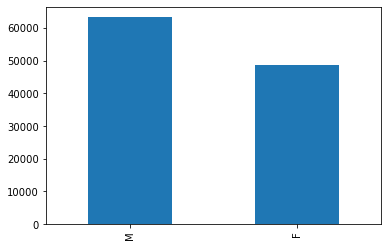

```python
#Gender count (in general)
print( "Ratio of Men in data", (all_xray_df['Patient Gender'] == 'M').sum() /len(all_xray_df))
print( "Ratio of Women in data", (all_xray_df['Patient Gender'] == 'F').sum() /len(all_xray_df))
pd.value_counts(all_xray_df['Patient Gender']).plot.bar()
```

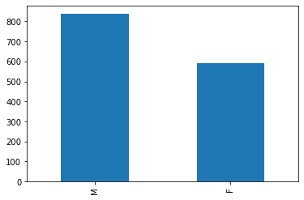

```python
# Gender count (when Pneomonia is present)
pd.value_counts(all_xray_df.loc[all_xray_df['Pneumonia'] == 1.0, 'Patient Gender'] ).plot.bar()
```

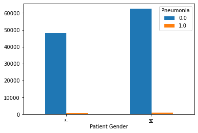

```python
pd.crosstab(all_xray_df['Patient Gender'],all_xray_df['Pneumonia']).plot.bar()
```

Age Distribution in general dataset as well as where Pneomonia is present

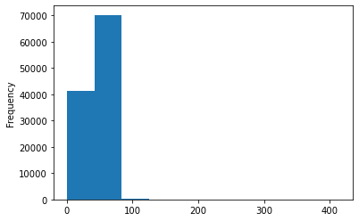

```python
all_xray_df['Patient Age'].plot.hist() # see how there are outliers in Age
```

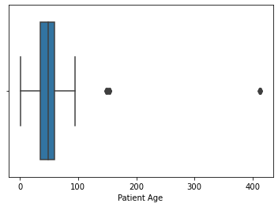

```python
sns.boxplot(x=all_xray_df['Patient Age'])# lets confirm outliers using box plot
```

```python
all_xray_df.loc[all_xray_df['Patient Age'] > 100, 'Patient Age'] = 0 # removing outliers, I am marking such outliers as 0
```

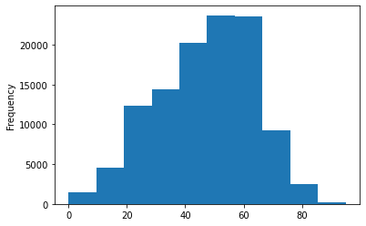

```python
all_xray_df['Patient Age'].plot.hist()
```

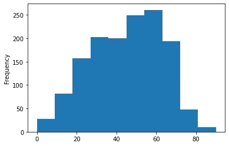

```python
all_xray_df.loc[all_xray_df['Pneumonia'] == 1.0, 'Patient Age'].plot.hist()
```

### The x-ray views taken (i.e. view position)

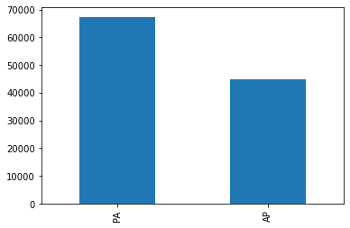

```python
# Patient x-ray position (present in whole dataset)
pd.value_counts(all_xray_df['View Position'] ).plot.bar()
```

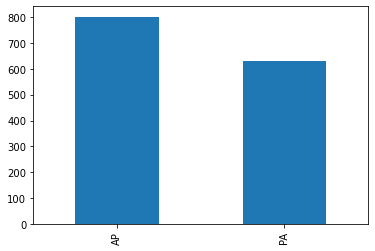

```python
# Patient x-ray position (when Pneomonia is present)
pd.value_counts(all_xray_df.loc[all_xray_df['Pneumonia'] == 1.0, 'View Position'] ).plot.bar()
```

```python
all_xray_df['View Position'].unique()
```

```
array(['PA', 'AP'], dtype=object)
```

### number of cases pneumonia Vs non pneumonia

```python
# number of pneumonia cases
p_count= [(all_xray_df['Pneumonia'] == 1.0).sum(), (all_xray_df['Pneumonia'] == 0.0).sum()]
print("No. of pneumonia cases " , p_count[0])
print("No. of non pneumonia cases " , p_count[1])
print("No. of pneumonia cases make up almost" , p_count[0]/len(all_xray_df), " of " ,
      len(all_xray_df), " cases")
```

```
No. of pneumonia cases  1431
No. of non pneumonia cases  110689
No. of pneumonia cases make up almost 0.012763110952550838  of  112120  cases
```

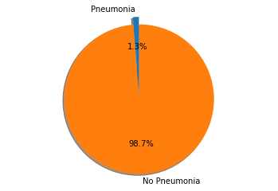

```python
# number of pneumonia cases visualisation
fig1, ax1 = plt.subplots()
labels = 'Pneumonia', 'No Pneumonia'
ax1.pie(p_count, explode=(0.1,0), labels=labels, autopct='%1.1f%%',
        shadow=True, startangle=90)
ax1.axis('equal')  # Equal aspect ratio ensures that pie is drawn as a circle.

plt.show()
```

### distribution of other diseases that are comorbid with pneumonia

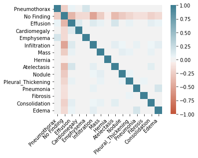

```python
corr = all_xray_df[['Pneumothorax',
 'No Finding',
 'Effusion',
 'Cardiomegaly',
 'Emphysema',
 'Infiltration',
 'Mass',
 'Hernia',
 'Atelectasis',
 'Nodule',
 'Pleural_Thickening',
 'Pneumonia',
 'Fibrosis',
 'Consolidation',
 'Edema']].corr()
ax = sns.heatmap(
    corr,
    vmin=-1, vmax=1, center=0,
    cmap=sns.diverging_palette(20, 220, n=200),
    square=True
)
ax.set_xticklabels(
    ax.get_xticklabels(),
    rotation=45,
    horizontalalignment='right'
);
```

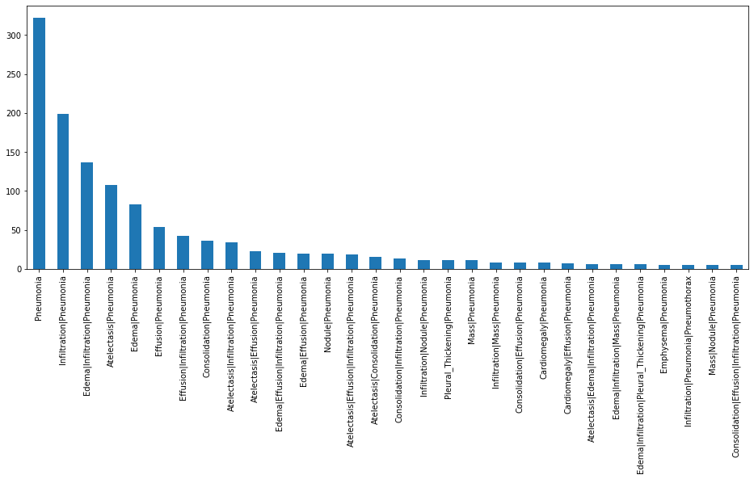

```python
##Since there are many combinations of potential findings, I'm going to look at the 30 most common co-occurrences:
plt.figure(figsize=(16,6))
all_xray_df[all_xray_df.Pneumonia==1]['Finding Labels'].value_counts()[0:30].plot(kind='bar')
```

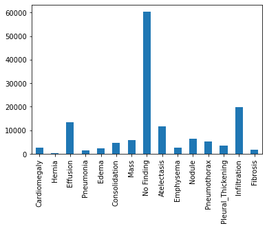

```python
all_xray_df[disease].sum().plot.bar(x='diesease')
```

### Number of disease per patient

```python
all_xray_df['Disease_count'] =  all_xray_df[['Pneumothorax',
 'No Finding',
 'Effusion',
 'Cardiomegaly',
 'Emphysema',
 'Infiltration',
 'Mass',
 'Hernia',
 'Atelectasis',
 'Nodule',
 'Pleural_Thickening',
 'Pneumonia',
 'Fibrosis',
 'Consolidation',
 'Edema']].sum(axis=1)
```

```python
all_xray_df['Disease_count'].unique()
```

```
array([1., 2., 4., 3., 5., 6., 7., 8., 9.])
```

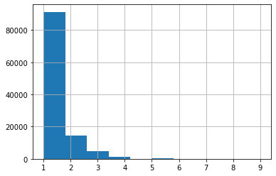

```python
all_xray_df['Disease_count'].hist(bins=10)
```

#### Findings from EDA

- There is a slight difference in the number of Female Vs Male present in the data, 14560 male are more than female in data.Similar difference is noted in patients with Pneumonia diagnosed
- Most of the patients in NIH data lies in age group 50-60
- Penumonia is diagnosed for almost all age groups, majority of case lies in 30-70 age group and the most cases are reported for 55-65 age group
- There are 2 distinct view position of X-ray ('PA', 'AP'), in overall dataset, x-rays of 'PA' view position (almost 70000) is more than 'AP' position (45000) but Pneomonia is present mostly in 'AP' x-ray position
- In overall dataset only 1.3 % cases are of Pneumonia, rest of 98.7 % are of non pneomonia, also in terms of gender specific diagnosis as well pneumonia is found very less in both Male and female in the overall dataset
- Most of the Pneomonia cases appears alone, the next major comorbidity is Infiltration, Edema+Infiltration, Atelectasis, Edema, Effusion
- No. of disease per patient is mostly 1 and sometime it is either 2, 3, and 4 and rarely reaches to 9

### Pixel-level assessments of the imaging data for healthy & disease states of interest

```python
# sample_df['Finding Labels'].unique()
disease = list(set([y for x in sample_df['Finding Labels'] for y in x.split('|')]))
for each in disease:
    sample_df[each] = sample_df['Finding Labels'].map(lambda finding:1.0 if each in finding else 0)
```

```python
sample_df
```

|  | Image Index | Finding Labels | Follow-up # | Patient ID | Patient Age | Patient Gender | View Position | OriginalImageWidth | OriginalImageHeight | OriginalImagePixelSpacing_x | ... | Hernia | Mass | No Finding | Atelectasis | Emphysema | Nodule | Pneumothorax | Pleural_Thickening | Infiltration | Fibrosis |
| --- | --- | --- | --- | --- | --- | --- | --- | --- | --- | --- | --- | --- | --- | --- | --- | --- | --- | --- | --- | --- | --- |
| 0 | 00000013_005.png | Emphysema\|Infiltration\|Pleural_Thickening\|Pneu... | 5 | 13 | 060Y | M | AP | 3056 | 2544 | 0.139000 | ... | 0.0 | 0.0 | 0.0 | 0.0 | 1.0 | 0.0 | 1.0 | 1.0 | 1.0 | 0.0 |
| 1 | 00000013_026.png | Cardiomegaly\|Emphysema | 26 | 13 | 057Y | M | AP | 2500 | 2048 | 0.168000 | ... | 0.0 | 0.0 | 0.0 | 0.0 | 1.0 | 0.0 | 0.0 | 0.0 | 0.0 | 0.0 |
| 2 | 00000017_001.png | No Finding | 1 | 17 | 077Y | M | AP | 2500 | 2048 | 0.168000 | ... | 0.0 | 0.0 | 1.0 | 0.0 | 0.0 | 0.0 | 0.0 | 0.0 | 0.0 | 0.0 |
| 3 | 00000030_001.png | Atelectasis | 1 | 30 | 079Y | M | PA | 2992 | 2991 | 0.143000 | ... | 0.0 | 0.0 | 0.0 | 1.0 | 0.0 | 0.0 | 0.0 | 0.0 | 0.0 | 0.0 |
| 4 | 00000032_001.png | Cardiomegaly\|Edema\|Effusion | 1 | 32 | 055Y | F | AP | 2500 | 2048 | 0.168000 | ... | 0.0 | 0.0 | 0.0 | 0.0 | 0.0 | 0.0 | 0.0 | 0.0 | 0.0 | 0.0 |
| ... | ... | ... | ... | ... | ... | ... | ... | ... | ... | ... | ... | ... | ... | ... | ... | ... | ... | ... | ... | ... | ... |
| 5601 | 00030712_000.png | No Finding | 0 | 30712 | 058Y | M | PA | 2021 | 2021 | 0.194311 | ... | 0.0 | 0.0 | 1.0 | 0.0 | 0.0 | 0.0 | 0.0 | 0.0 | 0.0 | 0.0 |
| 5602 | 00030786_005.png | Cardiomegaly\|Effusion\|Emphysema | 5 | 30786 | 061Y | F | AP | 3056 | 2544 | 0.139000 | ... | 0.0 | 0.0 | 0.0 | 0.0 | 1.0 | 0.0 | 0.0 | 0.0 | 0.0 | 0.0 |
| 5603 | 00030789_000.png | Infiltration | 0 | 30789 | 052Y | F | PA | 2021 | 2021 | 0.194311 | ... | 0.0 | 0.0 | 0.0 | 0.0 | 0.0 | 0.0 | 0.0 | 0.0 | 1.0 | 0.0 |
| 5604 | 00030792_000.png | No Finding | 0 | 30792 | 010Y | F | PA | 1775 | 1712 | 0.194311 | ... | 0.0 | 0.0 | 1.0 | 0.0 | 0.0 | 0.0 | 0.0 | 0.0 | 0.0 | 0.0 |
| 5605 | 00030797_000.png | No Finding | 0 | 30797 | 024Y | M | PA | 2021 | 2021 | 0.194311 | ... | 0.0 | 0.0 | 1.0 | 0.0 | 0.0 | 0.0 | 0.0 | 0.0 | 0.0 | 0.0 |

5606 rows × 26 columns

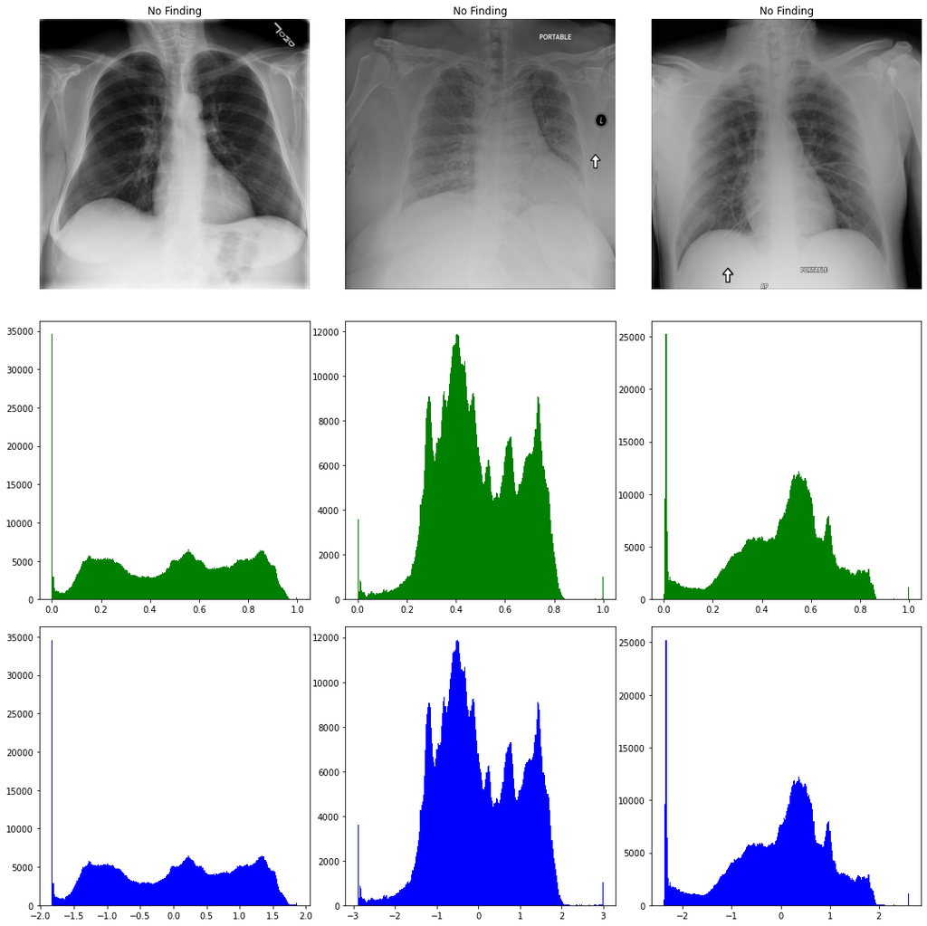

```python
fig,axes = plt.subplots(3,3, figsize=(15,15))
fig.tight_layout()

normal_data = sample_df[sample_df['Finding Labels'] == 'No Finding'].sample(3)
img_paths = [glob(f"/data/images*/*/{i}")[0] for i in normal_data['Image Index'].values]
for idx, each in enumerate(img_paths[:3]):
    ds = plt.imread(each)
#     print(ds)
    ds_flat = np.array(ds).ravel()
    mean = ds_flat.mean()
    std = np.std(ds_flat)
    normal = (ds_flat - mean) / std
    axes[0, idx].set_title(normal_data[normal_data['Image Index']== each.split('/')[-1]]['Finding Labels'].values[0])
    axes[0, idx].axis('Off')
    axes[0, idx].imshow(ds, cmap='gray')
    axes[1, idx].hist(np.array(ds).ravel(), bins = 256,color='green')
    axes[2, idx].hist(normal, bins = 256,color='blue')
```

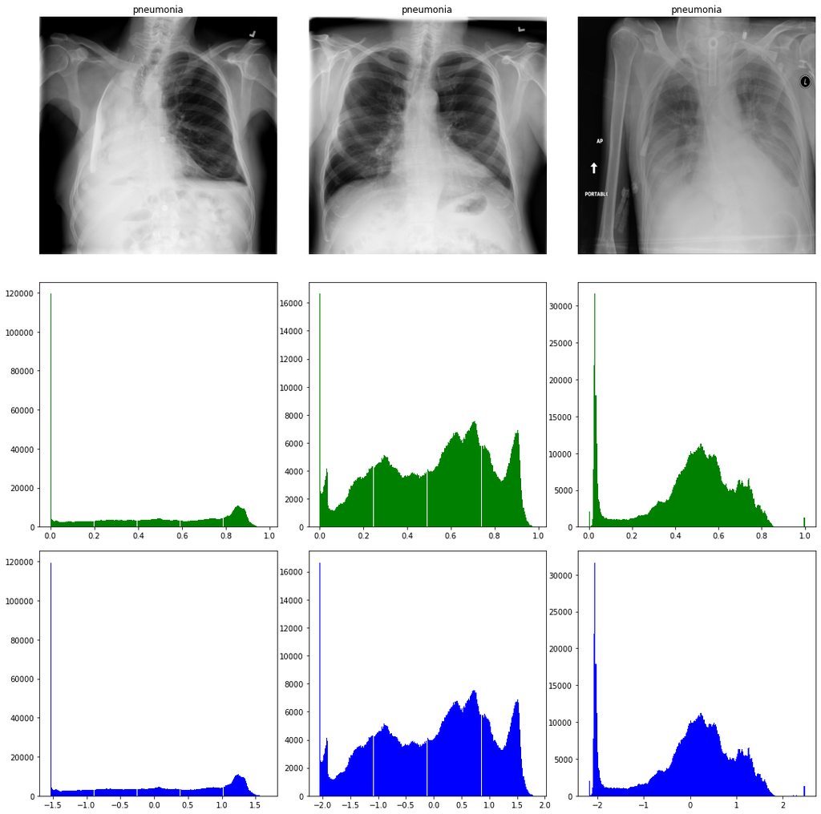

```python
fig,axes = plt.subplots(3,3, figsize=(15,15))
fig.tight_layout()

normal_data = sample_df[sample_df['Pneumonia'] == 1.0].sample(3)
img_paths = [glob(f"/data/images*/*/{i}")[0] for i in normal_data['Image Index'].values]
for idx, each in enumerate(img_paths[:3]):
    ds = plt.imread(each)
#     print(ds)
    ds_flat = np.array(ds).ravel()
    mean = ds_flat.mean()
    std = np.std(ds_flat)
    normal = (ds_flat - mean) / std
    axes[0, idx].set_title('pneumonia')
    axes[0, idx].imshow(ds, cmap='gray')
    axes[0, idx].axis('Off')
    axes[1, idx].hist(np.array(ds).ravel(), bins = 256,color='green')
    axes[2, idx].hist(normal, bins = 256,color='blue')
```

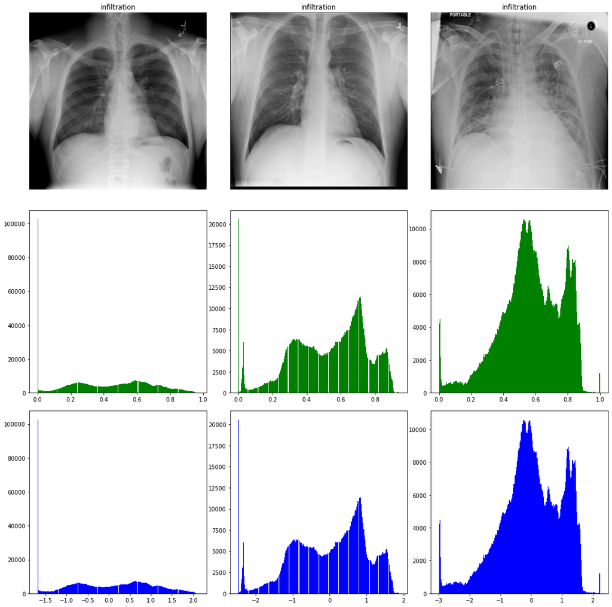

```python
fig,axes = plt.subplots(3,3, figsize=(15,15))
fig.tight_layout()

normal_data = sample_df[sample_df['Infiltration'] == 1.0].sample(3)
img_paths = [glob(f"/data/images*/*/{i}")[0] for i in normal_data['Image Index'].values]
for idx, each in enumerate(img_paths[:3]):
    ds = plt.imread(each)
#     print(ds)
    ds_flat = np.array(ds).ravel()
    mean = ds_flat.mean()
    std = np.std(ds_flat)
    normal = (ds_flat - mean) / std
    axes[0, idx].set_title('infiltration')
    axes[0, idx].imshow(ds, cmap='gray')
    axes[0, idx].axis('Off')
    axes[1, idx].hist(np.array(ds).ravel(), bins = 256,color='green')
    axes[2, idx].hist(normal, bins = 256,color='blue')
```

### Finding from intensity distribution

By looking at the intensity distribution of No finding, Pneomonia and Infiltration, I don't see any similarity in similar cases; which makes it an unreliable way to study these x-rays